# Membres de groupe

```r
#Mohamed El Baamrani
```

```r
#Reda Boubrik
```

```r
#Chihab Rahmani
```

```r
#Salma El Marzouki
```

# La démarche de modélisation

Analyse exploratoire : Que contient le jeu de données? Y a t-il beaucoup de valeurs manquantes?

Vérifier la liaison entre les variables descriptives et la variable à expliquer.

Identifier les prédicteurs importants et les redondants afin de faire un modèle parcimonieux (très important lorsqu'on souhaite faire de la prévision).

Estimer le modèle sur un échantillon d'apprentissage.

Valider le modèle sur un échantillon test et construire les indicateurs de qualité du modèle.

Comparer plusieurs modèles et retenir le modèle le plus adéquat selon l'objectif de l'étude.

```r
#Tout d’abord, on charge le jeu de données
train_Data<-read.csv("ScoringTraining.csv")
Test_Data<-read.csv("ScoringTest.csv")

#Supprimer X
train_Data$X<-NULL
Test_Data$X<-NULL
summary(train_Data)
```

```
 SeriousDlqin2yrs  RevolvingUtilizationOfUnsecuredLines      age
 Min.   :0.00000   Min.   :    0.00                     Min.   :  0.0
 1st Qu.:0.00000   1st Qu.:    0.03                     1st Qu.: 41.0
 Median :0.00000   Median :    0.15                     Median : 52.0
 Mean   :0.06684   Mean   :    6.05                     Mean   : 52.3
 3rd Qu.:0.00000   3rd Qu.:    0.56                     3rd Qu.: 63.0
 Max.   :1.00000   Max.   :50708.00                     Max.   :109.0

 NumberOfTime30.59DaysPastDueNotWorse   DebtRatio        MonthlyIncome
 Min.   : 0.000                       Min.   :     0.0   Min.   :      0
 1st Qu.: 0.000                       1st Qu.:     0.2   1st Qu.:   3400
 Median : 0.000                       Median :     0.4   Median :   5400
 Mean   : 0.421                       Mean   :   353.0   Mean   :   6670
 3rd Qu.: 0.000                       3rd Qu.:     0.9   3rd Qu.:   8249
 Max.   :98.000                       Max.   :329664.0   Max.   :3008750
                                                         NA's   :29731
 NumberOfOpenCreditLinesAndLoans NumberOfTimes90DaysLate
 Min.   : 0.000                  Min.   : 0.000
 1st Qu.: 5.000                  1st Qu.: 0.000
 Median : 8.000                  Median : 0.000
 Mean   : 8.453                  Mean   : 0.266
 3rd Qu.:11.000                  3rd Qu.: 0.000
 Max.   :58.000                  Max.   :98.000

 NumberRealEstateLoansOrLines NumberOfTime60.89DaysPastDueNotWorse
 Min.   : 0.000               Min.   : 0.0000
 1st Qu.: 0.000               1st Qu.: 0.0000
 Median : 1.000               Median : 0.0000
 Mean   : 1.018               Mean   : 0.2404
 3rd Qu.: 2.000               3rd Qu.: 0.0000
 Max.   :54.000               Max.   :98.0000

 NumberOfDependents
 Min.   : 0.000
 1st Qu.: 0.000
 Median : 0.000
 Mean   : 0.757
 3rd Qu.: 1.000
 Max.   :20.000
 NA's   :3924
```

La proportion de défaut est le ratio calculant le pourcentage de non-paiement des échéances d’un emprunt.

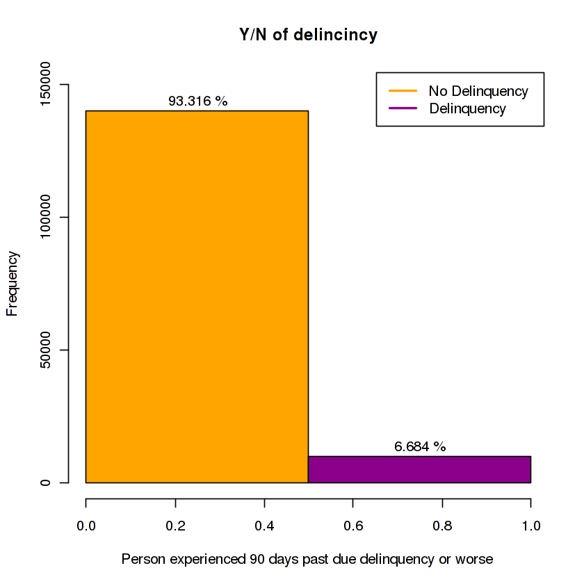

```r
#dessiner l'histogramme

h <- hist(train_Data$SeriousDlqin2yrs,
     main="Y/N of delincincy",
     xlab="Person experienced 90 days past due delinquency or worse ",
     xlim=c(0,1),
     ylim=c(0,150000),
     breaks=2,
     col=c("orange", "darkmagenta"),
     freq=TRUE
)
#ajouter les pourcentage

text(h$mids,h$counts,labels=paste((h$counts/150000)*100, "%"), adj=c(0.5, -0.5))

#ajouter la legend
legend("topright",
       inset = 0.01,
       legend = c("No Delinquency", "Delinquency"),
       col = c("orange", "darkmagenta"),
       lty = c(1, 1),
       lwd = 2,
       pt.cex = 2)
```

Afin de trouver les valeur aberrantes (anomalies) on va réaliser des boite à moustache pour les différentes variables.

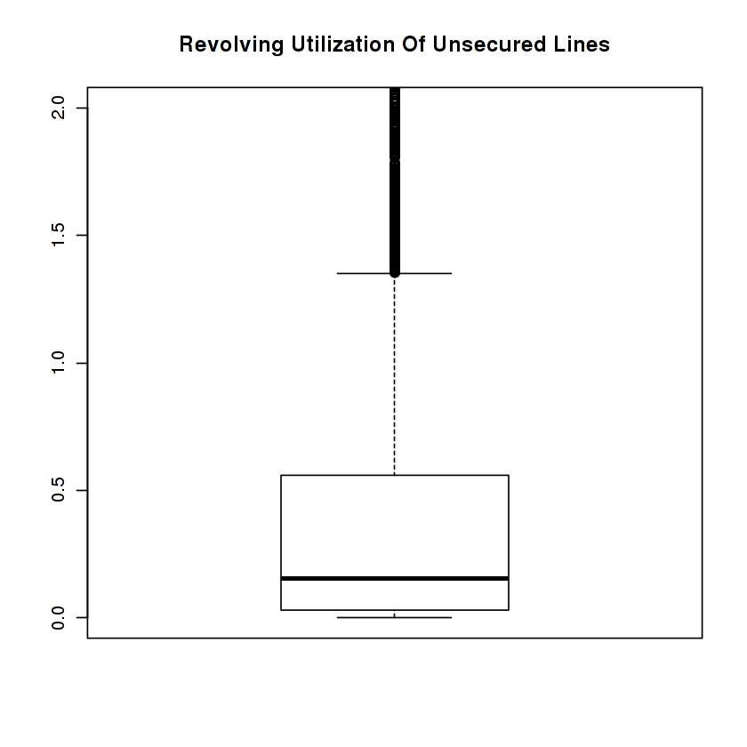

```r
boxplot(train_Data$RevolvingUtilizationOfUnsecuredLines,
        ylim=c(0,2),
        main="Revolving Utilization Of Unsecured Lines")
```

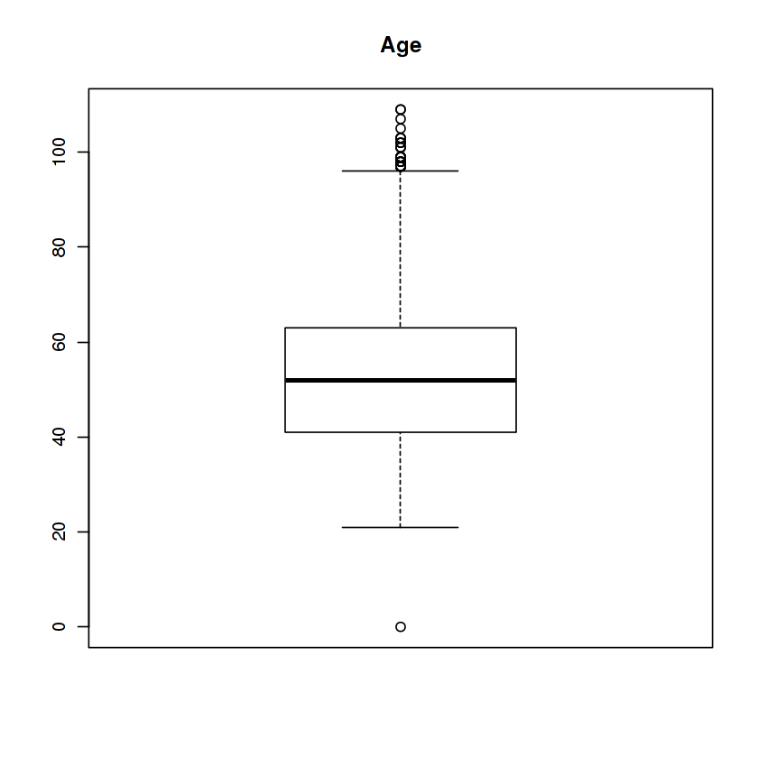

```r
boxplot(train_Data$age,
        main="Age")
```

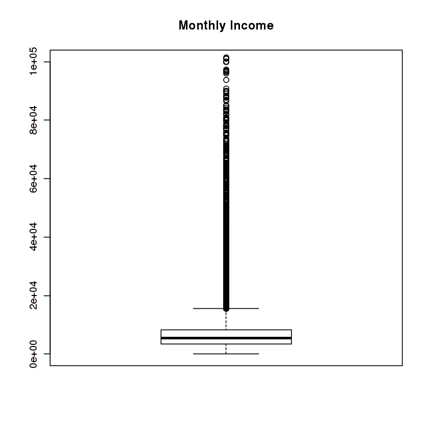

```r
boxplot(train_Data$MonthlyIncome, ylim=c(0,100000),
        main="Monthly Income")
```

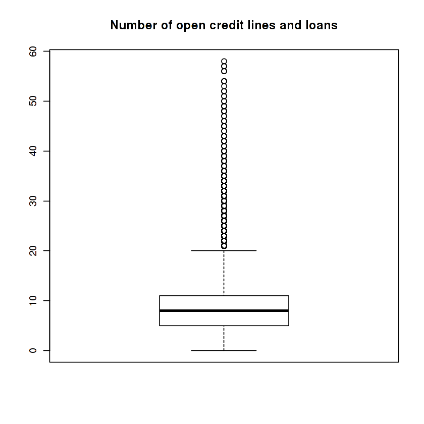

```r
boxplot(train_Data$NumberOfOpenCreditLinesAndLoans,
        main="Number of open credit lines and loans")
```

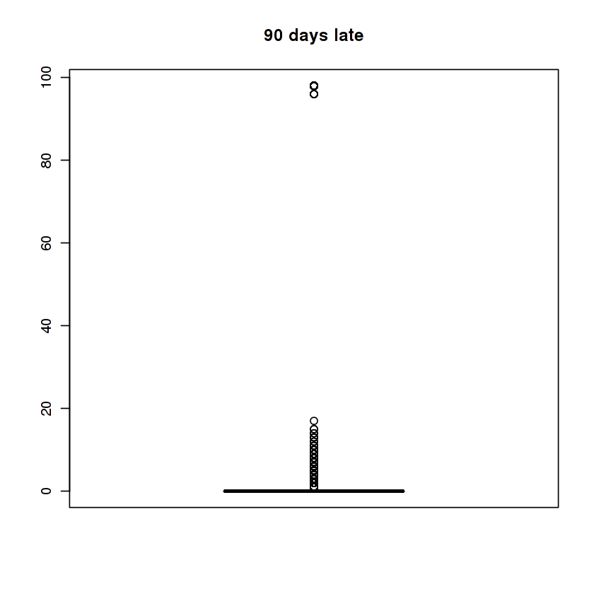

```r
boxplot(train_Data$NumberOfTimes90DaysLate,
        main="90 days late")
```

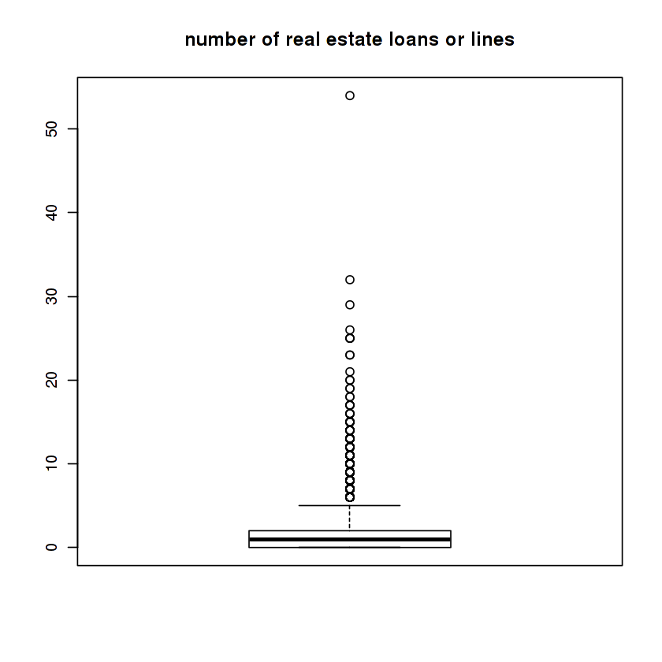

```r
boxplot(train_Data$NumberRealEstateLoansOrLines,
        main="number of real estate loans or lines")
```

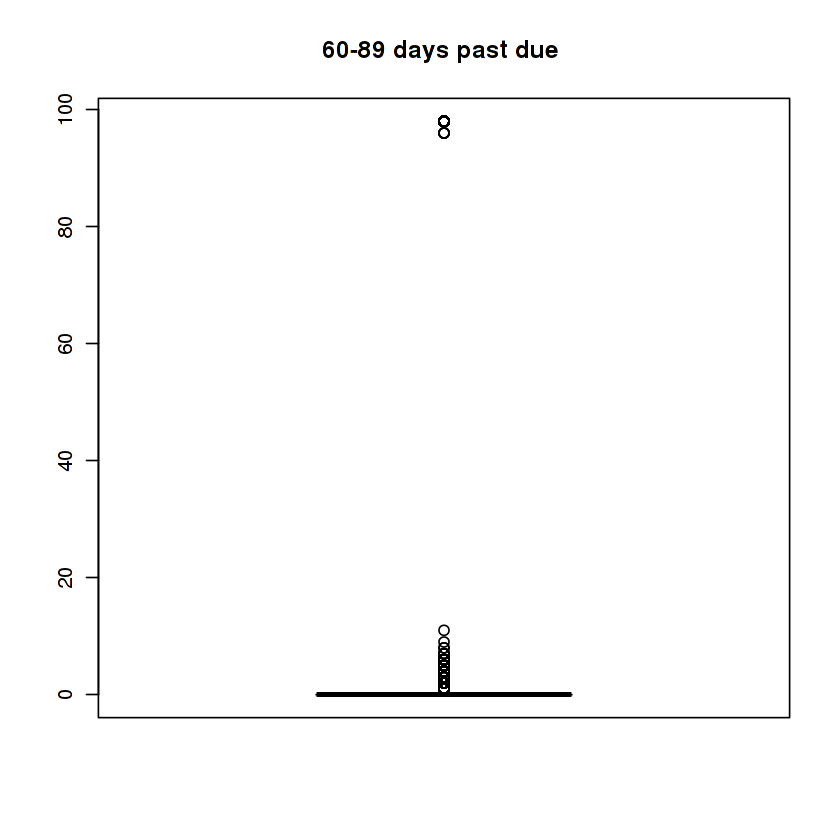

```r
boxplot(train_Data$NumberOfTime60.89DaysPastDueNotWorse,
        main="60-89 days past due ")
```

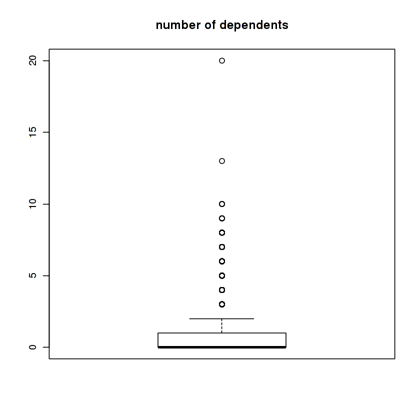

```r
boxplot(train_Data$NumberOfDependents,
        main="number of dependents")
```

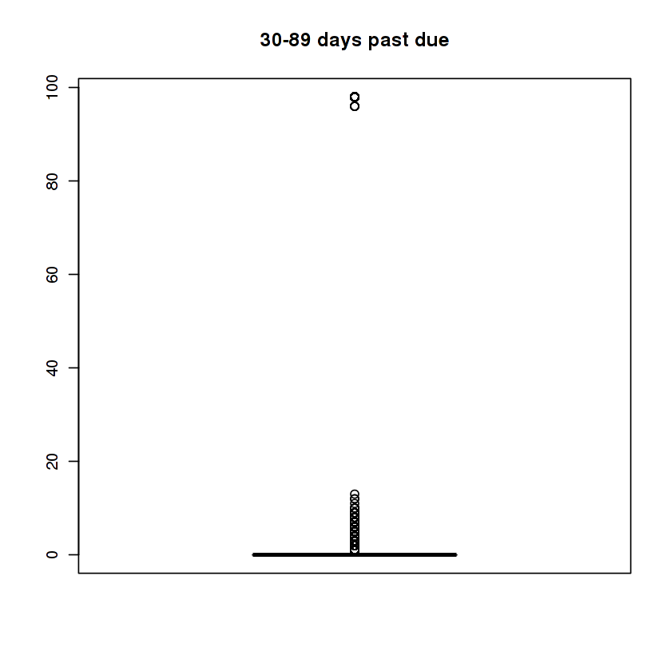

```r
boxplot(train_Data$NumberOfTime30.59DaysPastDueNotWorse,
        main="30-89 days past due")
```

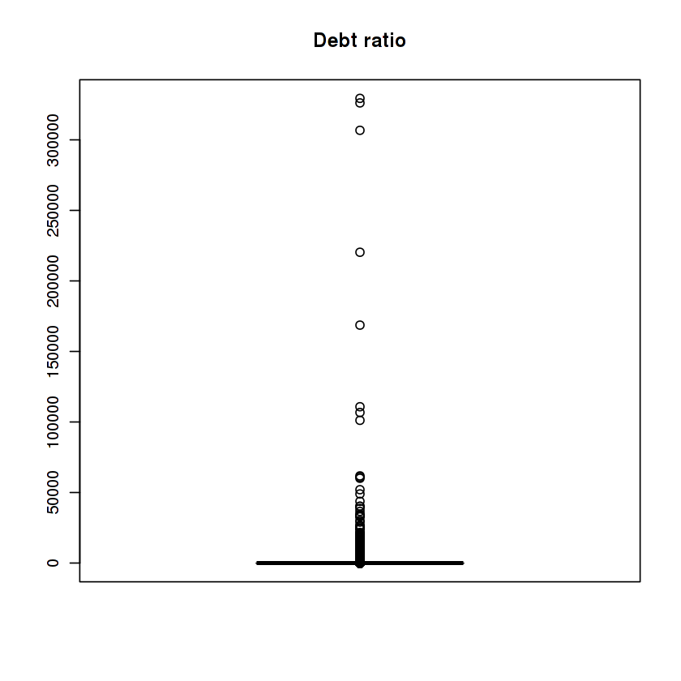

```r
boxplot(train_Data$DebtRatio,
        main="Debt ratio")
```

```r
#la distrubition des variables manquants
sapply(train_Data,function(x) sum(is.na(x)))
```

**SeriousDlqin2yrs**

0

**RevolvingUtilizationOfUnsecuredLines**

0

**age**

0

**NumberOfTime30.59DaysPastDueNotWorse**

0

**DebtRatio**

0

**MonthlyIncome**

29731

**NumberOfOpenCreditLinesAndLoans**

0

**NumberOfTimes90DaysLate**

0

**NumberRealEstateLoansOrLines**

0

**NumberOfTime60.89DaysPastDueNotWorse**

0

**NumberOfDependents**

3924

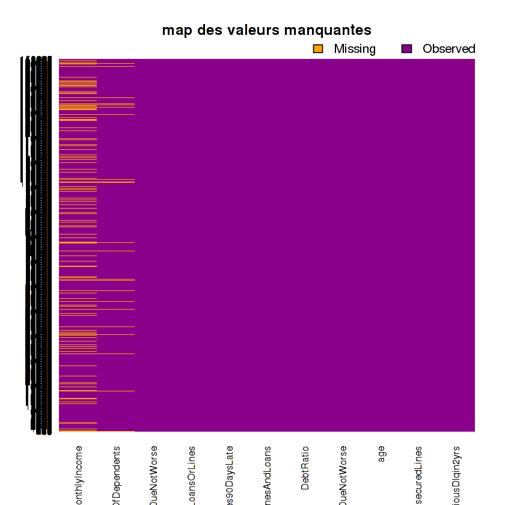

```r
#trouver les valeurs manquantes
library(Amelia)
missmap(train_Data,
        legend = TRUE,
        col = c("orange","darkmagenta"),
        main= "map des valeurs manquantes",
        yaxt='n')
```

```r
#corrigé les valeurs manquantes

train_Data$NumberOfDependents[is.na(train_Data$NumberOfDependents)] <- median(train_Data$NumberOfDependents,na.rm=T)
train_Data$MonthlyIncome[is.na(train_Data$MonthlyIncome)] <- median(train_Data$MonthlyIncome,na.rm=T)
```

```r
#la distrubition des variables manquants
sapply(train_Data,function(x) sum(is.na(x)))
```

**SeriousDlqin2yrs**

0

**RevolvingUtilizationOfUnsecuredLines**

0

**age**

0

**NumberOfTime30.59DaysPastDueNotWorse**

0

**DebtRatio**

0

**MonthlyIncome**

0

**NumberOfOpenCreditLinesAndLoans**

0

**NumberOfTimes90DaysLate**

0

**NumberRealEstateLoansOrLines**

0

**NumberOfTime60.89DaysPastDueNotWorse**

0

**NumberOfDependents**

0

```r
#cooriger outlier :
train_Data_no_outliers <- train_Data
```

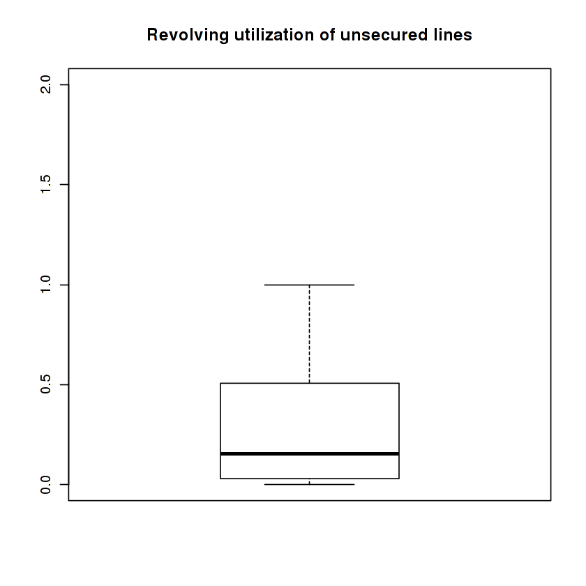

```r
#revolving
train_Data_no_outliers$RevolvingUtilizationOfUnsecuredLines[train_Data_no_outliers$RevolvingUtilizationOfUnsecuredLines>1]=median(train_Data_no_outliers$RevolvingUtilizationOfUnsecuredLines)

#If <0 -> 0 | If >1 -> 1
train_Data_no_outliers$RevolvingUtilizationOfUnsecuredLines<-ifelse(train_Data_no_outliers$RevolvingUtilizationOfUnsecuredLines<0,
                                                                    0,
                                                                    train_Data_no_outliers$RevolvingUtilizationOfUnsecuredLines)
train_Data_no_outliers$RevolvingUtilizationOfUnsecuredLines<-ifelse(train_Data_no_outliers$RevolvingUtilizationOfUnsecuredLines>1,
                                                                    1,train_Data_no_outliers$RevolvingUtilizationOfUnsecuredLines)


boxplot(train_Data_no_outliers$RevolvingUtilizationOfUnsecuredLines,
        ylim=c(0,2),
        main="Revolving utilization of unsecured lines")
```

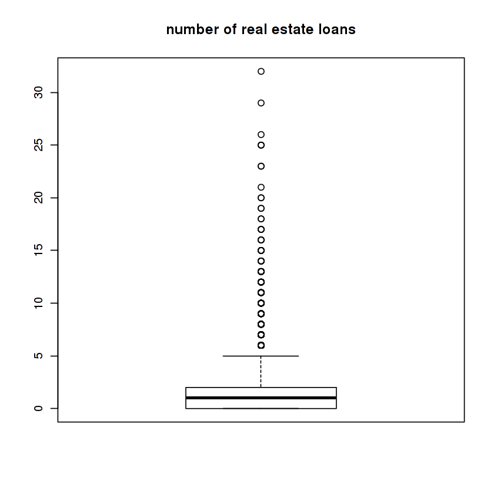

```r
#number of real estate
train_Data_no_outliers$NumberRealEstateLoansOrLines<-ifelse(train_Data_no_outliers$NumberRealEstateLoansOrLines==54,
                                                            median(train_Data_no_outliers$NumberOfOpenCreditLinesAndLoans),
                                                            train_Data_no_outliers$NumberRealEstateLoansOrLines)

boxplot(train_Data_no_outliers$NumberRealEstateLoansOrLines,
       main="number of real estate loans")
```

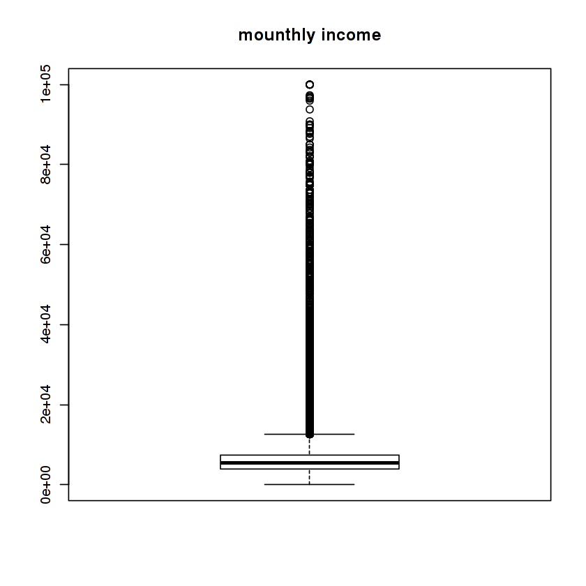

```r
#mountly income

train_Data_no_outliers$MonthlyIncome[(train_Data_no_outliers$MonthlyIncome)>100000]<-median(train_Data_no_outliers$MonthlyIncome,na.rm = TRUE)

boxplot(train_Data_no_outliers$MonthlyIncome,
        main="mounthly income")
```

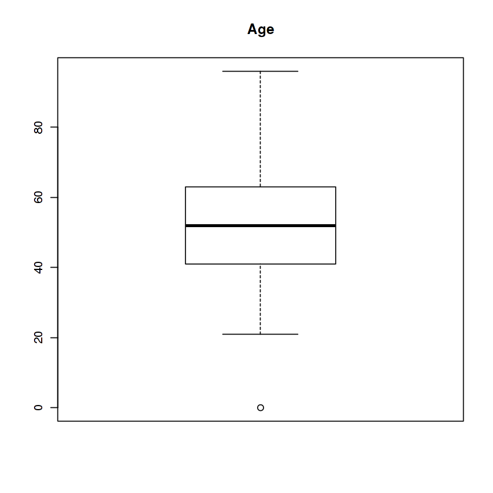

```r
#age

qnt <- quantile(train_Data_no_outliers$age, probs=c(.25, .75), na.rm = TRUE)
H <- 1.5 * IQR(train_Data_no_outliers$age, na.rm = TRUE)
train_Data_no_outliers$age <-ifelse(train_Data_no_outliers$age > (qnt[2] + H),median(train_Data_no_outliers$age),train_Data_no_outliers$age)

boxplot(train_Data_no_outliers$age,
        main="Age")
```

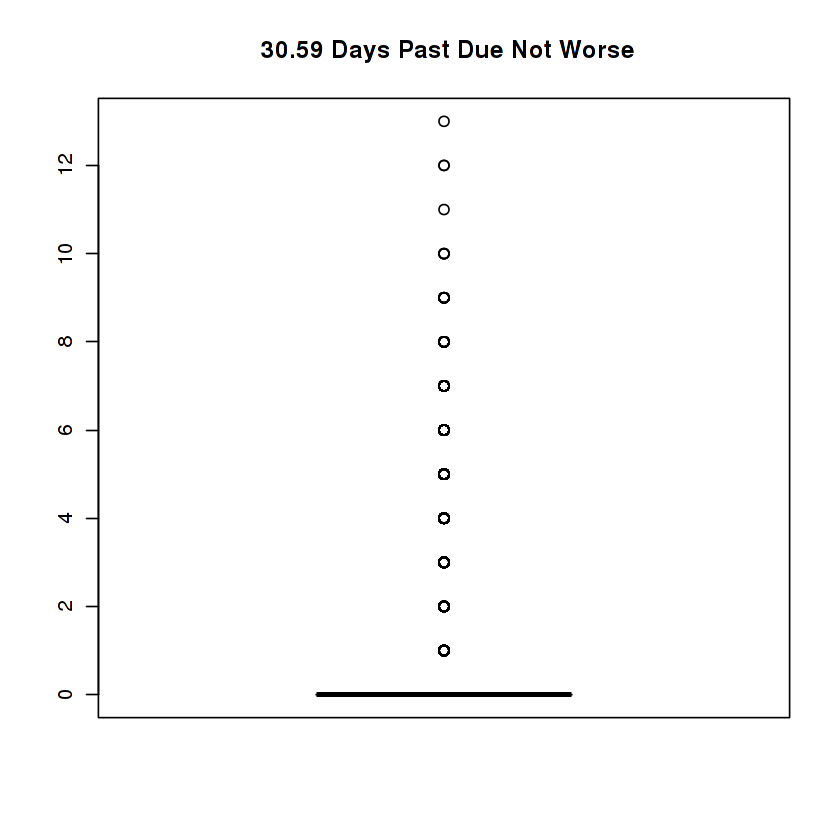

```r
#30-59 days

train_Data_no_outliers$NumberOfTime30.59DaysPastDueNotWorse[train_Data_no_outliers$NumberOfTime30.59DaysPastDueNotWorse>=50]<-0

boxplot(train_Data_no_outliers$NumberOfTime30.59DaysPastDueNotWorse,
        main=" 30.59 Days Past Due Not Worse")
```

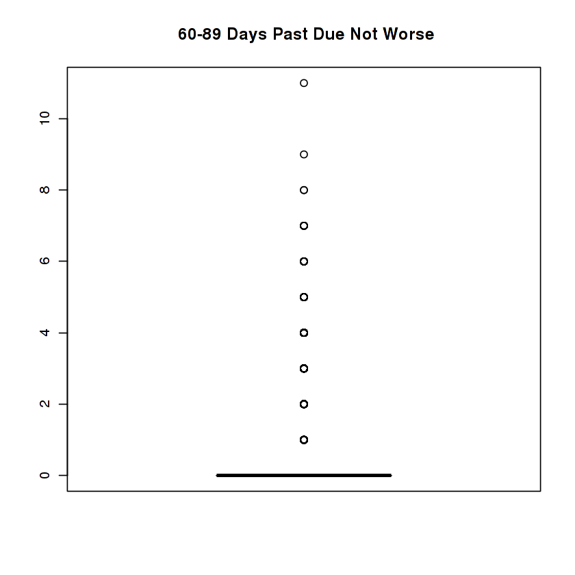

```r
#60 days
train_Data_no_outliers$NumberOfTime60.89DaysPastDueNotWorse[train_Data_no_outliers$NumberOfTime60.89DaysPastDueNotWorse>50]<-0

boxplot(train_Data_no_outliers$NumberOfTime60.89DaysPastDueNotWorse,
        main=" 60-89 Days Past Due Not Worse")
```

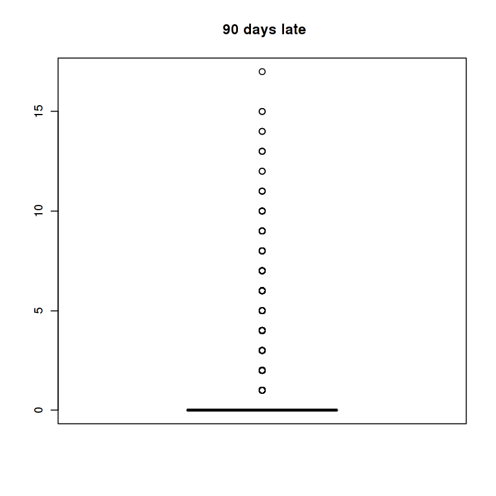

```r
# 90 days
train_Data_no_outliers$NumberOfTimes90DaysLate<-ifelse(train_Data_no_outliers$NumberOfTimes90DaysLate>50,0,train_Data_no_outliers$NumberOfTimes90DaysLate)

boxplot(train_Data_no_outliers$NumberOfTimes90DaysLate,
        main=" 90 days late")
```

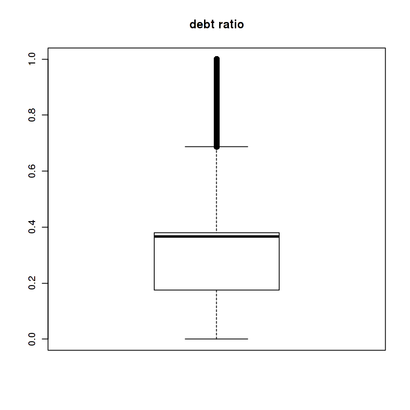

```r
# debt ratio
train_Data_no_outliers$DebtRatio<-ifelse(train_Data_no_outliers$DebtRatio<0,median(train_Data_no_outliers$DebtRatio),train_Data_no_outliers$DebtRatio)
train_Data_no_outliers$DebtRatio<-ifelse(train_Data_no_outliers$DebtRatio>1,median(train_Data_no_outliers$DebtRatio),train_Data_no_outliers$DebtRatio)

boxplot(train_Data_no_outliers$DebtRatio,
        main="debt ratio")
```

```r
###Nous avons presque 93% de la population qui appartiennent à la classe 0 et 6% appartenant à la classe 1.
###Notre but est d’équilibrer les deux classes de façon à avoir 50% de la classe 0 et 50% de la classe 1####
```

[output not shown]

```r
#Equilibrage des données
library(caret)
myData <- train_Data_no_outliers

down_sample <-sample(1:139974,11000)


DataOne <-myData[myData$SeriousDlqin2yrs==1,]
DataZero<-myData[myData$SeriousDlqin2yrs==0,]

newData <- rbind(DataOne,DataZero[down_sample,])
newData <- newData[sample(nrow(newData)),]

rownames(newData)<-NULL

#On convertit tout d’abord la variable SeriousDlqin2yrs en factor :
nd <- factor(newData$SeriousDlqin2yrs)
d <- downSample(newData,nd)
table(d$SeriousDlqin2yrs)

lda_1_data <- d
lda_2_data <- d
qda_data <- d
logistic_data <- d
```

```
    0     1
10026 10026
```

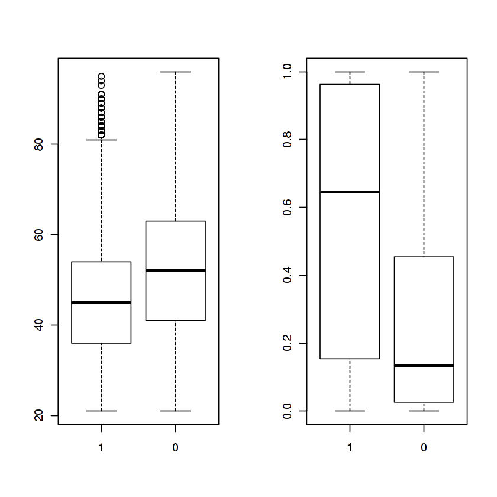

```r
par(mfrow=c(1,2))

d$SeriousDlqin2yrs<-factor(d$SeriousDlqin2yrs, levels=c(1,0))
boxplot(d$age~d$SeriousDlqin2yrs,d)
boxplot(d$RevolvingUtilization~d$SeriousDlqin2yrs,d)
```

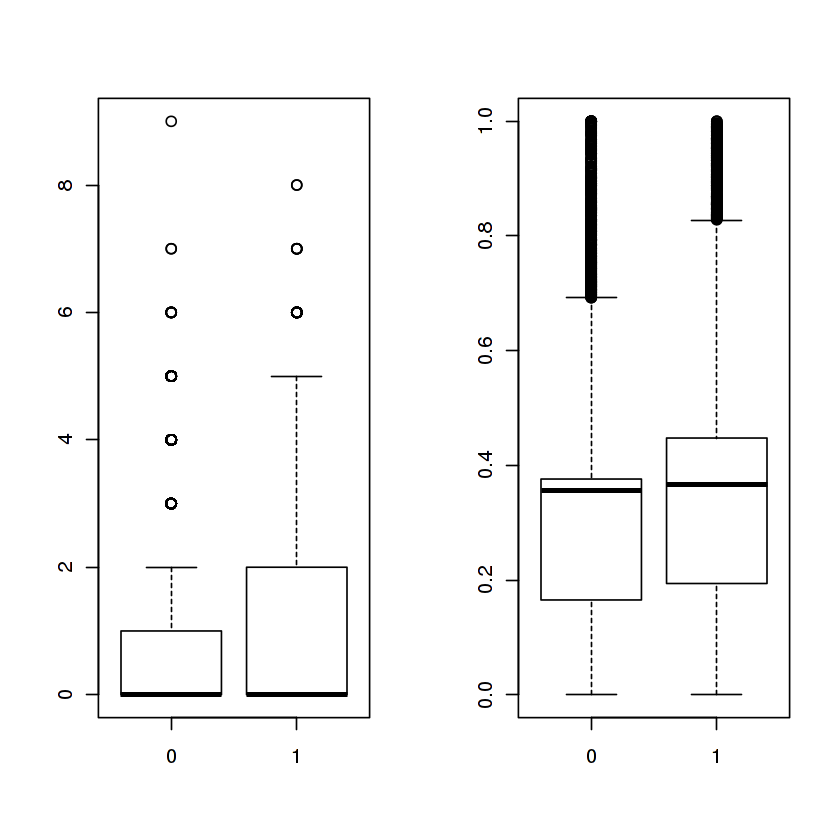

```r
par(mfrow=c(1,2))

boxplot(newData$NumberOfDependents~newData$SeriousDlqin2yrs,newData)
boxplot(newData$DebtRatio~newData$SeriousDlqin2yrs,newData)
```

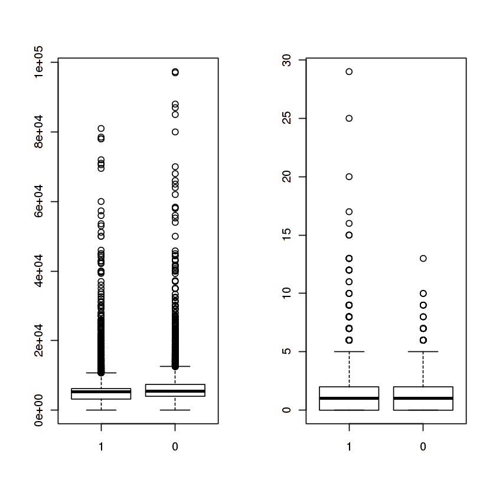

```r
par(mfrow=c(1,2))

boxplot(d$MonthlyIncome~d$SeriousDlqin2yrs,d)
boxplot(d$NumberRealEstateLoansOrLines~d$SeriousDlqin2yrs,d)
```

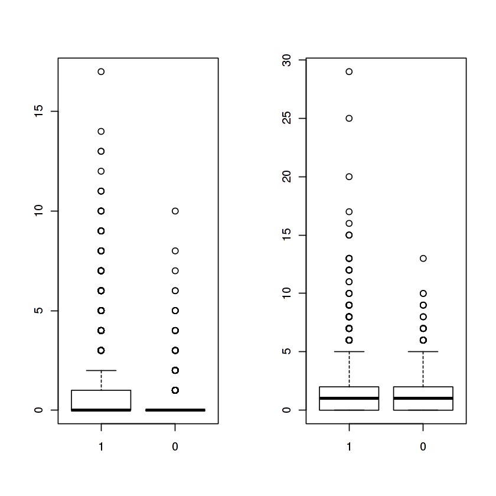

```r
par(mfrow=c(1,2))

boxplot(d$NumberOfTimes90DaysLate~d$SeriousDlqin2yrs,d)
boxplot(d$NumberRealEstateLoansOrLines~d$SeriousDlqin2yrs,d)
```

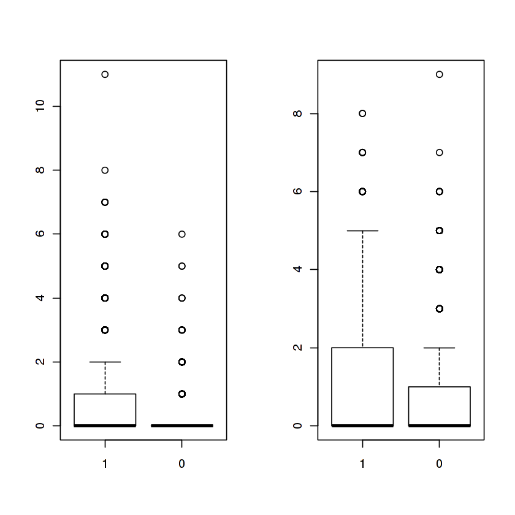

```r
par(mfrow=c(1,2))

boxplot(d$NumberOfTime60.89DaysPastDueNotWorse~d$SeriousDlqin2yrs,d)
boxplot(d$NumberOfDependents~d$SeriousDlqin2yrs,d)
```